# Fitting rates of change

Prediction C and D

Anthony Davidson

2019-05-16

# Overview

This report investigates the estimation of the rates of change between seasons. The data is in a similar structure as historically used for estimation of numerical and functional responses.

# Introduction

*Generally look at thesis drafts here.*

These files are the supporting documetation to the data-wrangling code in the Beech forest manuscript here.

But there is also many other supporting resources and less formal tutorials on my [website](https://www.ssnhub.com).

# Methods

This report breaks down the parameter estimates from the bayesian hierarical model in the context of our predictions and the data we collected.

## Data

First the dat for each parameter needs to be extracted and plotted. It can be hard to extract the information needed from a Bayesian output so I have left this for another vignette. For now I have just extracted the needed inforamtion for this paper.

*I Have used the following two datasets generated from the `Davidson_2019_Data_warngling.RMD` file*

```
Observations: 144
Variables: 31
$ N              <dbl> 85.185920, 141.346453, 125.542907, 23.769273, 8...
$ se.N           <dbl> 17.258336, 24.813696, 15.717429, 1.661358, 18.5...
$ lcl.N          <dbl> 53, 103, 100, 22, 57, 88, 93, 25, 13, 0, 1, 1, ...
$ ucl.N          <dbl> 114, 200, 162, 28, 125, 179, 164, 43, 26, 5, 5,...
$ var            <chr> "N[1,1]", "N[2,1]", "N[3,1]", "N[4,1]", "N[5,1]...
$ grid           <chr> "egl M1", "egl M1", "egl M1", "egl M1", "egl M1...
$ trip           <dbl> 1, 2, 3, 4, 5, 6, 7, 8, 9, 10, 11, 12, 13, 14, ...
$ grid.n         <dbl> 1, 1, 1, 1, 1, 1, 1, 1, 1, 1, 1, 1, 1, 1, 1, 1,...
$ trip.no        <dbl> 1, 2, 3, 4, 5, 6, 7, 8, 9, 10, 11, 12, 13, 14, ...
$ valley         <chr> "egl", "egl", "egl", "egl", "egl", "egl", "egl"...
$ control        <chr> "control", "control", "control", "control", "co...
$ Valley         <chr> "Eglinton", "Eglinton", "Eglinton", "Eglinton",...
$ year           <dbl> 1999, 1999, 1999, 2000, 2000, 2000, 2000, 2001,...
```

[output cut: 18 more lines]

```
Observations: 144
Variables: 41
$ N              <dbl> 85.185920, 141.346453, 125.542907, 23.769273, 8...
$ se.N           <dbl> 17.258336, 24.813696, 15.717429, 1.661358, 18.5...
$ lcl.N          <dbl> 53, 103, 100, 22, 57, 88, 93, 25, 13, 0, 1, 1, ...
$ ucl.N          <dbl> 114, 200, 162, 28, 125, 179, 164, 43, 26, 5, 5,...
$ var            <chr> "N[1,1]", "N[2,1]", "N[3,1]", "N[4,1]", "N[5,1]...
$ grid           <chr> "egl M1", "egl M1", "egl M1", "egl M1", "egl M1...
$ trip           <dbl> 1, 2, 3, 4, 5, 6, 7, 8, 9, 10, 11, 12, 13, 14, ...
$ grid.n         <dbl> 1, 1, 1, 1, 1, 1, 1, 1, 1, 1, 1, 1, 1, 1, 1, 1,...
$ trip.no.x      <dbl> 1, 2, 3, 4, 5, 6, 7, 8, 9, 10, 11, 12, 13, 14, ...
$ valley         <chr> "egl", "egl", "egl", "egl", "egl", "egl", "egl"...
$ control        <chr> "control", "control", "control", "control", "co...
$ Valley.x       <chr> "Eglinton", "Eglinton", "Eglinton", "Eglinton",...
$ year           <dbl> 1999, 1999, 1999, 2000, 2000, 2000, 2000, 2001,...
```

[output cut: 28 more lines]

```
Observations: 12
Variables: 11
$ Valley        <chr> "egl", "egl", "egl", "egl", "hol", "hol", "hol",...
$ Control       <chr> "control", "control", "control", "control", "con...
$ month         <chr> "Aug", "Feb", "May", "Nov", "Aug", "Feb", "May",...
$ dat.seed.mean <dbl> 2.0064741, 0.4730018, 1.5706454, 2.0113793, 1.89...
$ dat.rat.mean  <dbl> 1.750000, 5.500000, 2.875000, 2.000000, 3.666667...
$ dat.mice.min  <dbl> 1.4344200, 0.9671600, 0.5977067, 0.5596733, 2.32...
$ dat.seed.min  <dbl> 0, 0, 0, 0, 0, 0, 0, 0, 0, 0, 0, 0
$ dat.rat.min   <dbl> 1, 1, 1, 1, 1, 1, 1, 2, 1, 1, 1, 1
$ dat.mice.max  <dbl> 251.787493, 46.925373, 89.530253, 145.631960, 22...
$ dat.seed.max  <dbl> 3290.04329, 30.55768, 2648.33206, 3386.80927, 23...
$ dat.rat.max   <dbl> NA, NA, NA, NA, NA, NA, 19, NA, NA, 17, NA, NA
```

# PLots

- Parameter estimates: n = 48
- Rate of change: n = 136

## All February data

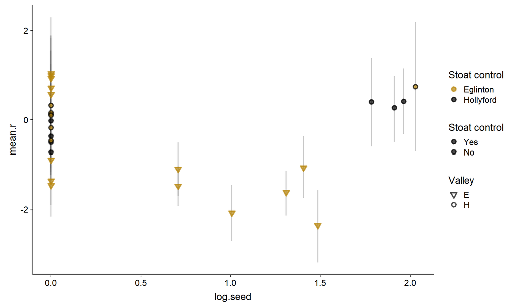

## All May data

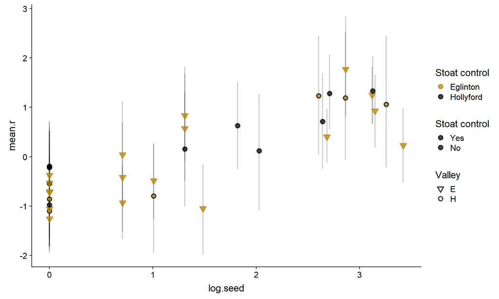

## All August data

### Autumn and Winter trends

- Rate of increase between Autumn and Winter
- (May and August rate of change)
- May mice abundace, seed and rat data

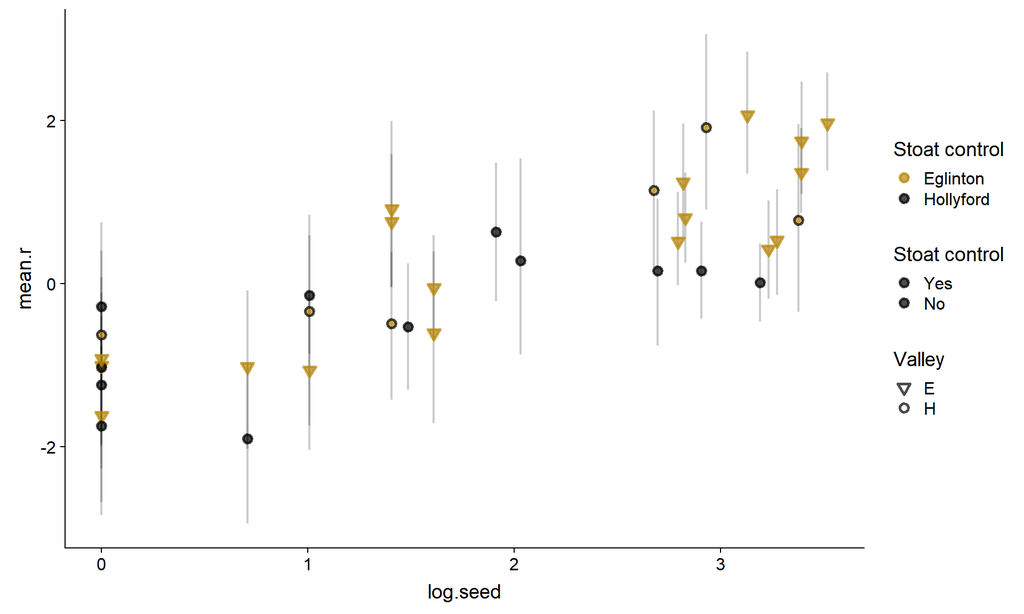

## All November data

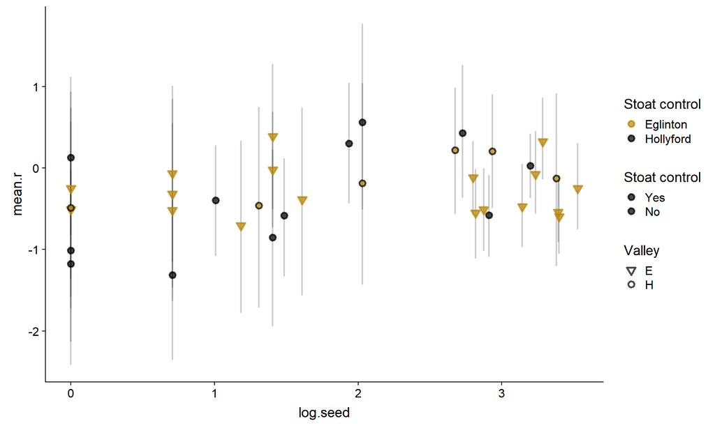

# Estimating lines

This is where it gets really tricky. I have done this in a way that works. I am sure there are better ways to code this but that is for a later date.

My steps are:

1. `out.final1` and filter out only month of interest
2. Find max values
- background points
2. `spread` data across the different parameter estimates
3. reduce the `out.full.136` to only `feb`
4. Merge with parameter dataset (steps1-2)
5. Plot away using `ggplot2`

## Seed

### All months

This is ok becuase the average estimates of line will all use the same average to estimate the trend line.

#### Fitted plot

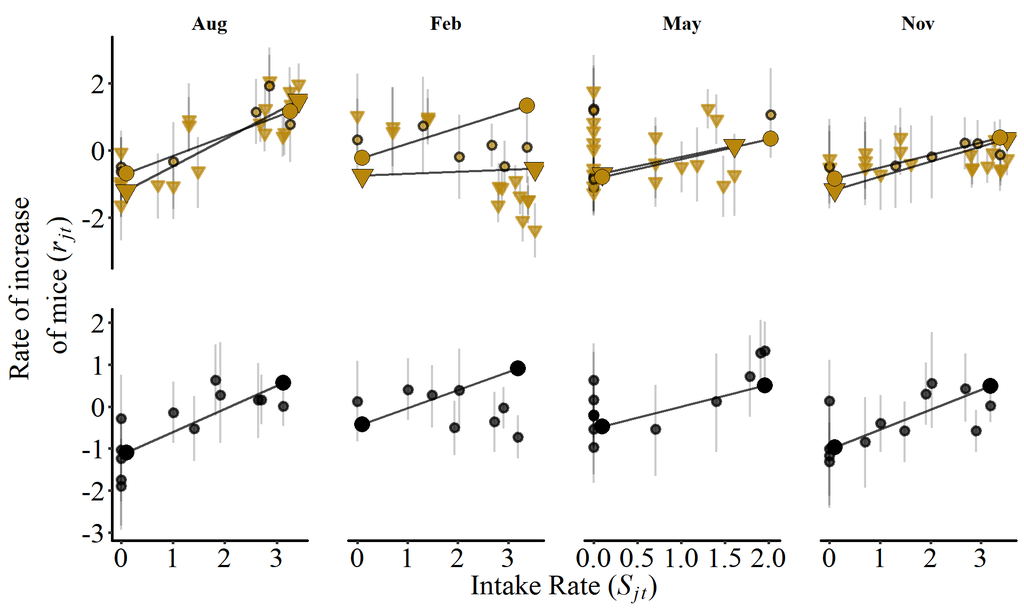

### August trend

This phase (Autumn to winter) has the strongest effect of `intake rate` on the population growth rates ($r_{jt}$).

#### Fitted plot

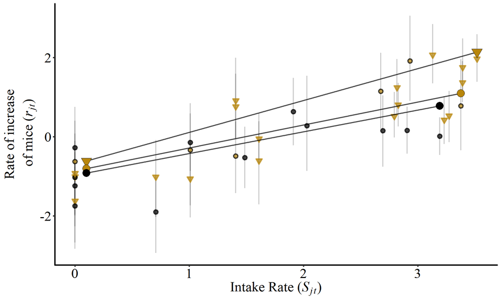

## Density

### All months

#### Fitted plot

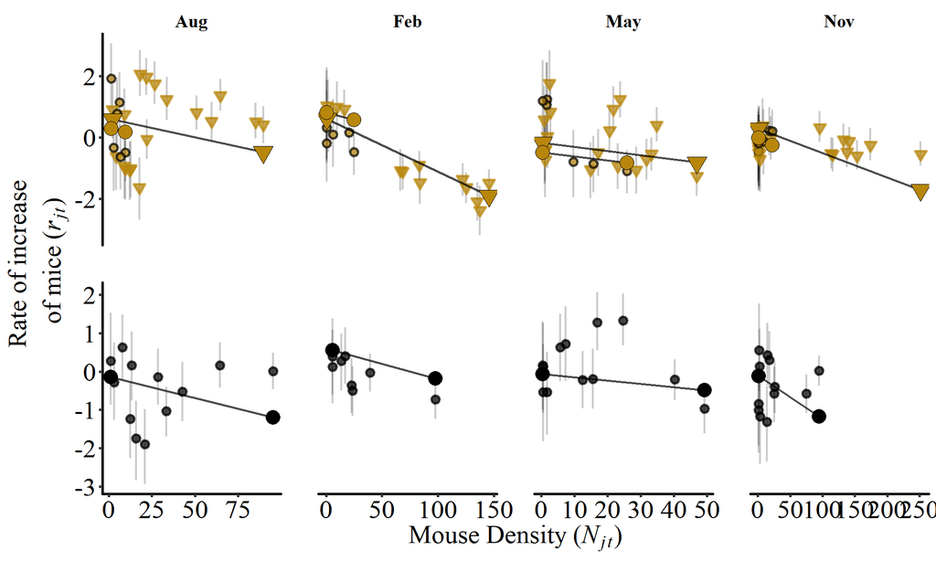

### February

#### Fitted plot

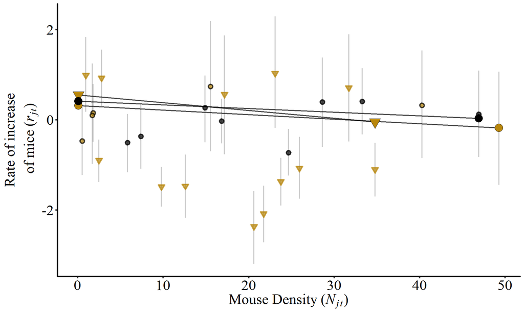

### May

#### Fitted plot

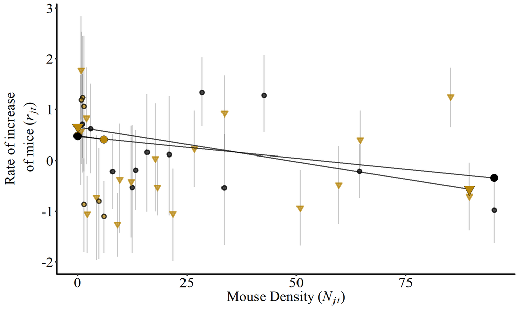

### Aug

#### Fitted plot

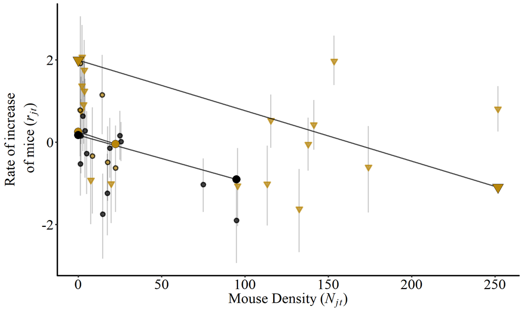

### Nov

#### Fitted plot

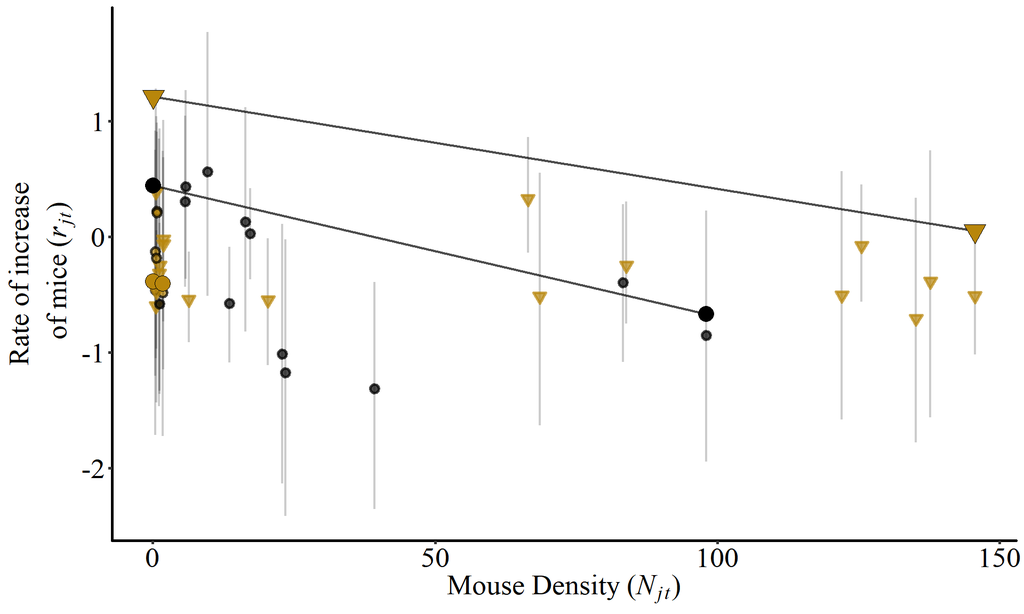

## Rats

### All months

#### Fitted plot

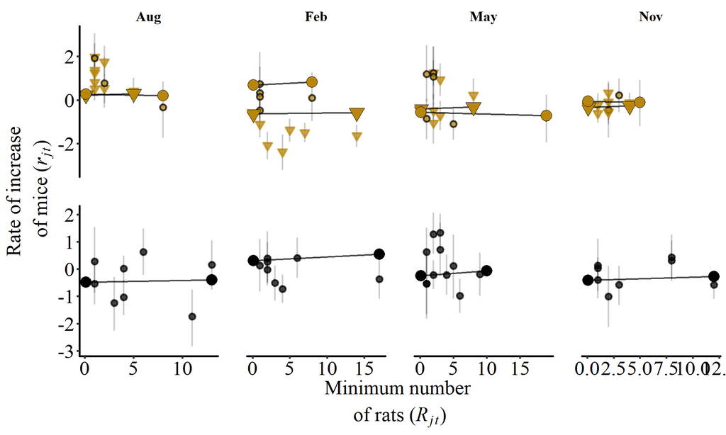

### Fitted plot

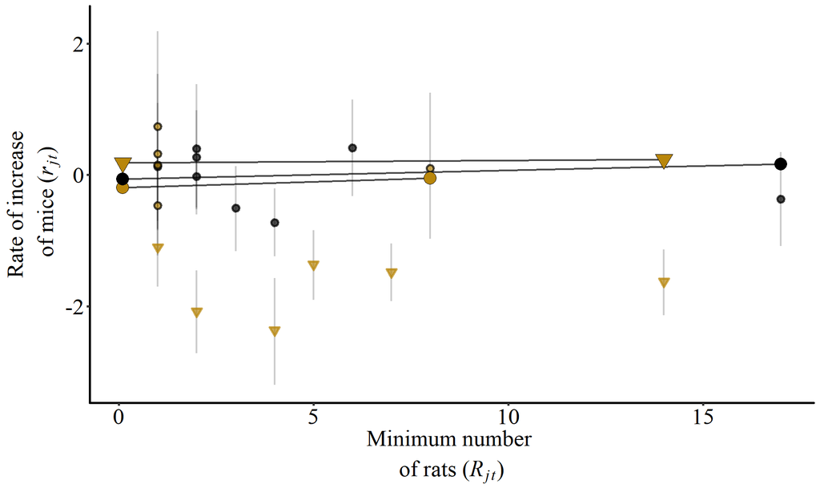

# Results

## Prediction C: Autumn and Winter trends

- Rate of increase between Autumn and Winter
- (May and August rate of change)
- May mice abundace, seed and rat data

[figure not shown]

## Prediction D: Spring and Summer trends

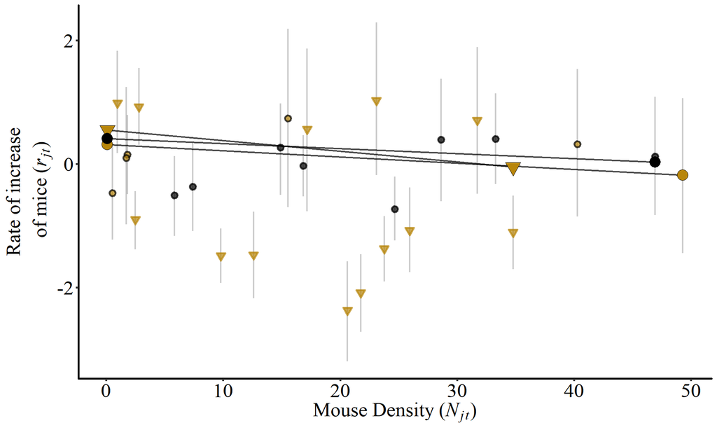

## Prediction E: Effect of rats

### Co-effiecents

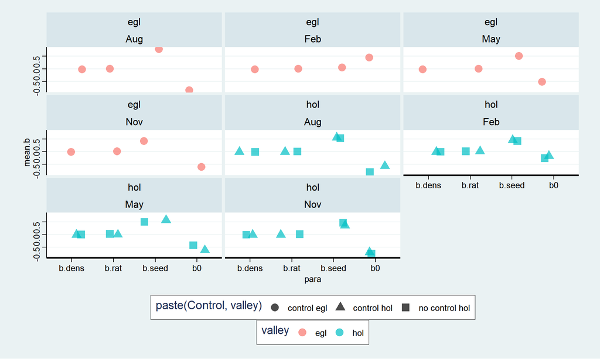

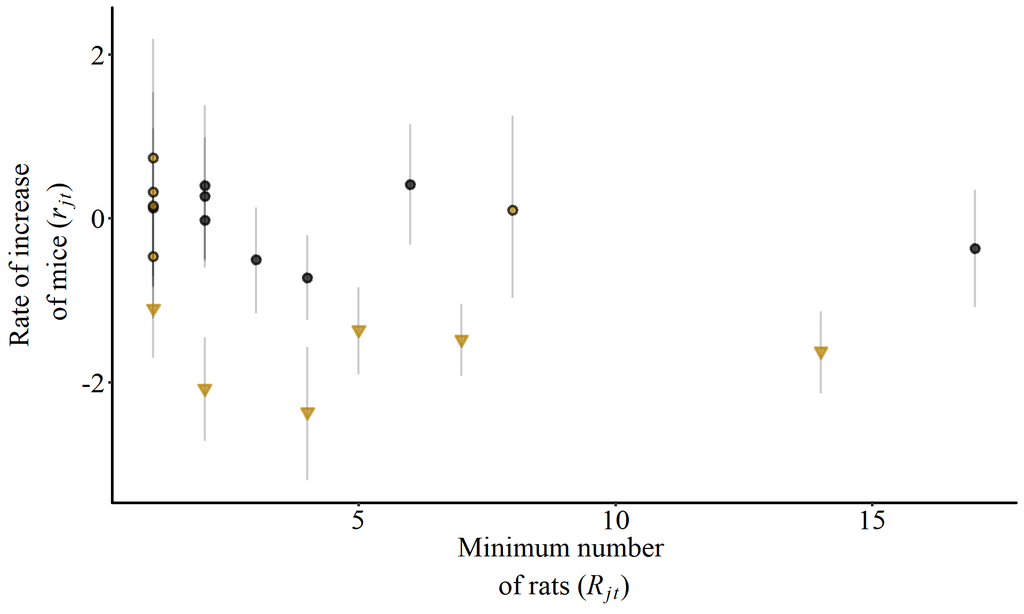

# Saving

## Saving

Must be `png`